# Meta-analysis of BCG vaccine trials with metafor

Random-effects model, heterogeneity, publication bias and moderators

Ahmed Hamdy

2026-10-27

## 1. Question and data

**Question:** does BCG vaccination reduce the risk of tuberculosis, and does the effect differ between studies?

**Data:** the classic `dat.bcg` dataset shipped with the `metafor` package (Colditz et al. 1994): 13 randomized or quasi-randomized trials. For each trial it reports the number of tuberculosis cases and non-cases in the vaccinated (`tpos`, `tneg`) and control (`cpos`, `cneg`) groups, plus the absolute latitude of the study site (`ablat`) and the allocation method (`alloc`).

This project covers the **statistical meta-analysis** step. It does not include a literature search, screening or risk-of-bias assessment.

```r
library(metafor)
```

```r
dat.bcg
```

```
##    trial               author year tpos  tneg cpos  cneg ablat      alloc
## 1      1              Aronson 1948    4   119   11   128    44     random
## 2      2     Ferguson & Simes 1949    6   300   29   274    55     random
## 3      3      Rosenthal et al 1960    3   228   11   209    42     random
## 4      4    Hart & Sutherland 1977   62 13536  248 12619    52     random
## 5      5 Frimodt-Moller et al 1973   33  5036   47  5761    13  alternate
## 6      6      Stein & Aronson 1953  180  1361  372  1079    44  alternate
## 7      7     Vandiviere et al 1973    8  2537   10   619    19     random
## 8      8           TPT Madras 1980  505 87886  499 87892    13     random
## 9      9     Coetzee & Berjak 1968   29  7470   45  7232    27     random
## 10    10      Rosenthal et al 1961   17  1699   65  1600    42 systematic
## 11    11       Comstock et al 1974  186 50448  141 27197    18 systematic
## 12    12   Comstock & Webster 1969    5  2493    3  2338    33 systematic
## 13    13       Comstock et al 1976   27 16886   29 17825    33 systematic
```

## 2. Effect sizes

The effect measure is the log risk ratio (vaccinated vs control). A value below zero means fewer cases among the vaccinated.

```r
dat <- escalc(measure = "RR", ai = tpos, bi = tneg, ci = cpos, di = cneg,
              data = dat.bcg)
dat$study <- paste(dat$author, dat$year, sep = ", ")
dat[, c("study", "yi", "vi")]
```

```
##
##                         study      yi     vi
## 1               Aronson, 1948 -0.8893 0.3256
## 2      Ferguson & Simes, 1949 -1.5854 0.1946
## 3       Rosenthal et al, 1960 -1.3481 0.4154
## 4     Hart & Sutherland, 1977 -1.4416 0.0200
## 5  Frimodt-Moller et al, 1973 -0.2175 0.0512
## 6       Stein & Aronson, 1953 -0.7861 0.0069
## 7      Vandiviere et al, 1973 -1.6209 0.2230
## 8            TPT Madras, 1980  0.0120 0.0040
## 9      Coetzee & Berjak, 1968 -0.4694 0.0564
## 10      Rosenthal et al, 1961 -1.3713 0.0730
## 11       Comstock et al, 1974 -0.3394 0.0124
## 12   Comstock & Webster, 1969  0.4459 0.5325
## 13       Comstock et al, 1976 -0.0173 0.0714
```

## 3. Random-effects meta-analysis

A random-effects model (REML) allows the true effect to differ between trials.

```r
res <- rma(yi, vi, data = dat, method = "REML", slab = dat$study)
summary(res)
```

```
##
## Random-Effects Model (k = 13; tau^2 estimator: REML)
##
##   logLik  deviance       AIC       BIC      AICc
## -12.2024   24.4047   28.4047   29.3746   29.7381
##
## tau^2 (estimated amount of total heterogeneity): 0.3132 (SE = 0.1664)
## tau (square root of estimated tau^2 value):      0.5597
## I^2 (total heterogeneity / total variability):   92.22%
## H^2 (total variability / sampling variability):  12.86
##
## Test for Heterogeneity:
## Q(df = 12) = 152.2330, p-val < .0001
##
## Model Results:
##
## estimate      se     zval    pval    ci.lb    ci.ub
##  -0.7145  0.1798  -3.9744  <.0001  -1.0669  -0.3622  ***
##
## ---
## Signif. codes:  0 '***' 0.001 '**' 0.01 '*' 0.05 '.' 0.1 ' ' 1
```

```r
# Pooled estimate back-transformed to a risk ratio
predict(res, transf = exp, digits = 2)
```

```
##
##  pred ci.lb ci.ub pi.lb pi.ub
##  0.49  0.34  0.70  0.15  1.55
```

## 4. Forest plot

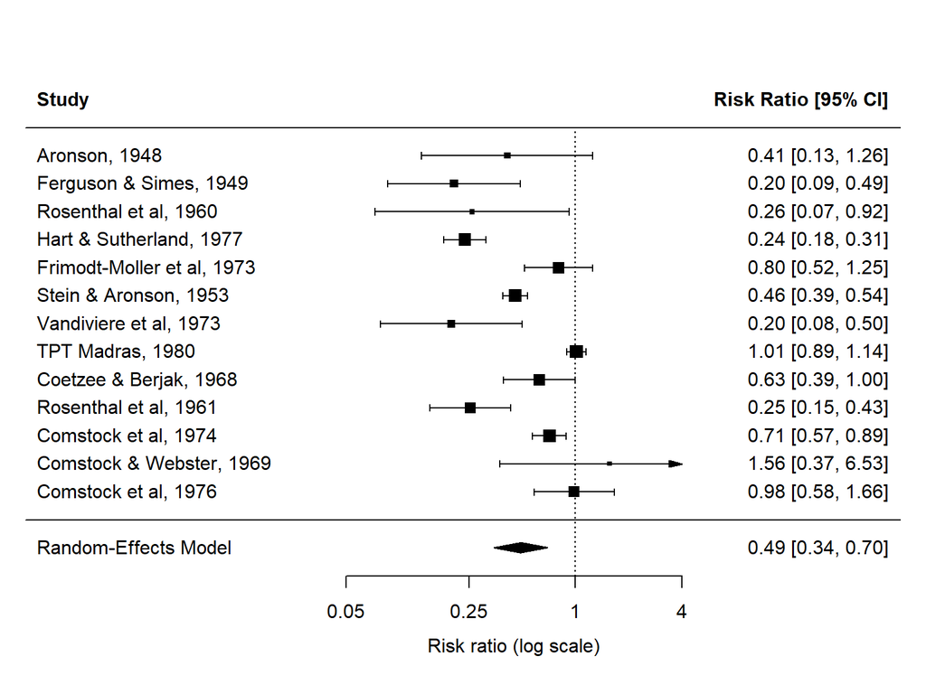

```r
forest(res, atransf = exp, at = log(c(0.05, 0.25, 1, 4)),
       header = TRUE, xlab = "Risk ratio (log scale)")
```

## 5. Heterogeneity

`tau^2` is the between-study variance, `I^2` the percentage of total variability due to heterogeneity, and `Q` tests whether the trials share one true effect.

```r
data.frame(tau2 = res$tau2, I2 = res$I2, H2 = res$H2,
           Q = res$QE, Q_pvalue = res$QEp)
```

```
##        tau2       I2       H2       Q     Q_pvalue
## 1 0.3132433 92.22139 12.85576 152.233 1.996765e-26
```

```r
# Prediction interval on the risk-ratio scale
predict(res, transf = exp, digits = 2)
```

```
##
##  pred ci.lb ci.ub pi.lb pi.ub
##  0.49  0.34  0.70  0.15  1.55
```

## 6. Publication bias

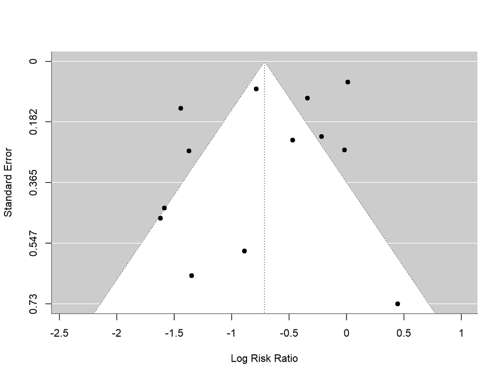

```r
funnel(res)
```

```r
regtest(res)            # Egger-type regression test
```

```
##
## Regression Test for Funnel Plot Asymmetry
##
## Model:     mixed-effects meta-regression model
## Predictor: standard error
##
## Test for Funnel Plot Asymmetry: z = -0.8033, p = 0.4218
## Limit Estimate (as sei -> 0):   b = -0.5104 (CI: -1.1182, 0.0974)
```

```r
trimfill(res)           # trim-and-fill adjusted estimate
```

```
##
## Estimated number of missing studies on the right side: 1 (SE = 2.4528)
##
## Random-Effects Model (k = 14; tau^2 estimator: REML)
##
## tau^2 (estimated amount of total heterogeneity): 0.3313 (SE = 0.1701)
## tau (square root of estimated tau^2 value):      0.5756
## I^2 (total heterogeneity / total variability):   92.14%
## H^2 (total variability / sampling variability):  12.72
##
## Test for Heterogeneity:
## Q(df = 13) = 154.6750, p-val < .0001
##
## Model Results:
##
## estimate      se     zval    pval    ci.lb    ci.ub
##  -0.6571  0.1785  -3.6805  0.0002  -1.0070  -0.3072  ***
##
## ---
## Signif. codes:  0 '***' 0.001 '**' 0.01 '*' 0.05 '.' 0.1 ' ' 1
```

## 7. Sensitivity: leave-one-out

```r
l1 <- leave1out(res, transf = exp)
out <- data.frame(omitted = dat$study, as.data.frame(l1)[, c("estimate", "ci.lb", "ci.ub", "I2")])
out
```

```
##                                                omitted  estimate     ci.lb     ci.ub
## -Aronson, 1948                           Aronson, 1948 0.4930800 0.3397992 0.7155048
## -Ferguson & Simes, 1949         Ferguson & Simes, 1949 0.5199455 0.3648797 0.7409110
## -Rosenthal et al, 1960           Rosenthal et al, 1960 0.5038108 0.3501016 0.7250049
## -Hart & Sutherland, 1977       Hart & Sutherland, 1977 0.5334396 0.3773522 0.7540907
## -Frimodt-Moller et al, 1973 Frimodt-Moller et al, 1973 0.4657203 0.3197976 0.6782270
## -Stein & Aronson, 1953           Stein & Aronson, 1953 0.4912134 0.3317521 0.7273221
## -Vandiviere et al, 1973         Vandiviere et al, 1973 0.5193135 0.3645947 0.7396884
## -TPT Madras, 1980                     TPT Madras, 1980 0.4516862 0.3174860 0.6426122
## -Coetzee & Berjak, 1968         Coetzee & Berjak, 1968 0.4765430 0.3241098 0.7006677
## -Rosenthal et al, 1961           Rosenthal et al, 1961 0.5204648 0.3626959 0.7468617
## -Comstock et al, 1974             Comstock et al, 1974 0.4686689 0.3193097 0.6878920
## -Comstock & Webster, 1969     Comstock & Webster, 1969 0.4677543 0.3273570 0.6683653
## -Comstock et al, 1976             Comstock et al, 1976 0.4595368 0.3194419 0.6610721
##                                   I2
## -Aronson, 1948              93.22593
## -Ferguson & Simes, 1949     92.25396
## -Rosenthal et al, 1960      92.93541
## -Hart & Sutherland, 1977    90.41247
## -Frimodt-Moller et al, 1973 92.76344
## -Stein & Aronson, 1953      90.91181
## -Vandiviere et al, 1973     92.27772
## -TPT Madras, 1980           87.03137
## -Coetzee & Berjak, 1968     93.21326
## -Rosenthal et al, 1961      92.23223
## -Comstock et al, 1974       91.81095
## -Comstock & Webster, 1969   92.67821
## -Comstock et al, 1976       92.34440
```

## 8. Explaining heterogeneity: moderators

Absolute latitude is a known moderator of BCG efficacy. A meta-regression tests whether the effect changes with latitude.

```r
res.lat <- rma(yi, vi, mods = ~ ablat, data = dat, method = "REML")
summary(res.lat)
```

```
##
## Mixed-Effects Model (k = 13; tau^2 estimator: REML)
##
##   logLik  deviance       AIC       BIC      AICc
##  -8.0873   16.1746   22.1746   23.3683   25.6032
##
## tau^2 (estimated amount of residual heterogeneity):     0.0764 (SE = 0.0591)
## tau (square root of estimated tau^2 value):             0.2763
## I^2 (residual heterogeneity / unaccounted variability): 68.39%
## H^2 (unaccounted variability / sampling variability):   3.16
## R^2 (amount of heterogeneity accounted for):            75.62%
##
## Test for Residual Heterogeneity:
## QE(df = 11) = 30.7331, p-val = 0.0012
##
## Test of Moderators (coefficient 2):
## QM(df = 1) = 16.3571, p-val < .0001
##
## Model Results:
##
##          estimate      se     zval    pval    ci.lb    ci.ub
## intrcpt    0.2515  0.2491   1.0095  0.3127  -0.2368   0.7397
## ablat     -0.0291  0.0072  -4.0444  <.0001  -0.0432  -0.0150  ***
##
## ---
## Signif. codes:  0 '***' 0.001 '**' 0.01 '*' 0.05 '.' 0.1 ' ' 1
```

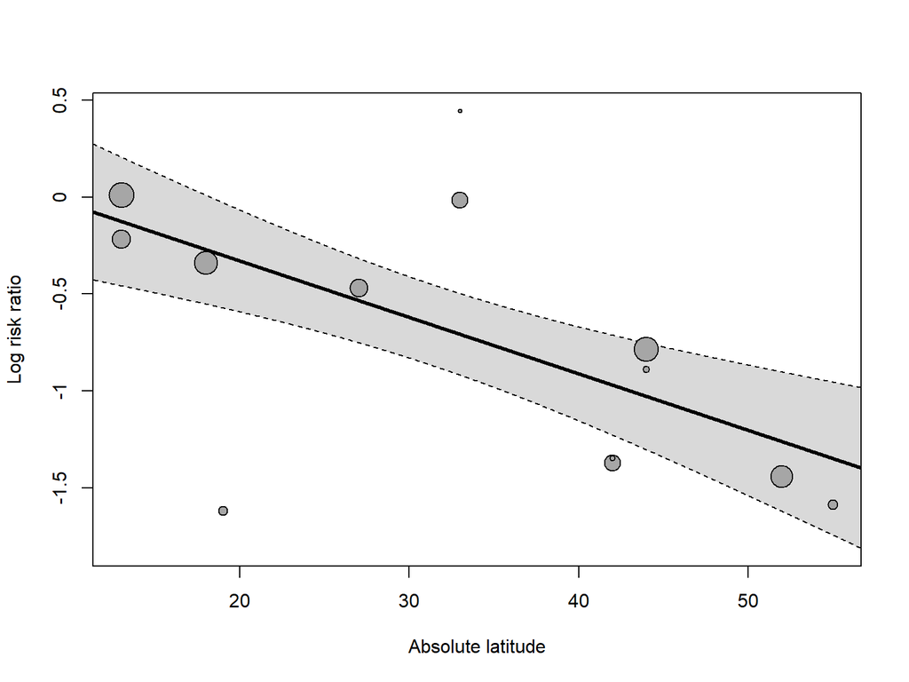

```r
regplot(res.lat, mod = "ablat", xlab = "Absolute latitude",
        ylab = "Log risk ratio")
```

Allocation method as a categorical moderator:

```r
res.alloc <- rma(yi, vi, mods = ~ factor(alloc), data = dat, method = "REML")
res.alloc
```

```
##
## Mixed-Effects Model (k = 13; tau^2 estimator: REML)
##
## tau^2 (estimated amount of residual heterogeneity):     0.3615 (SE = 0.2111)
## tau (square root of estimated tau^2 value):             0.6013
## I^2 (residual heterogeneity / unaccounted variability): 88.77%
## H^2 (unaccounted variability / sampling variability):   8.91
## R^2 (amount of heterogeneity accounted for):            0.00%
##
## Test for Residual Heterogeneity:
## QE(df = 10) = 132.3676, p-val < .0001
##
## Test of Moderators (coefficients 2:3):
## QM(df = 2) = 1.7675, p-val = 0.4132
##
## Model Results:
##
##                          estimate      se     zval    pval    ci.lb   ci.ub
## intrcpt                   -0.5180  0.4412  -1.1740  0.2404  -1.3827  0.3468
## factor(alloc)random       -0.4478  0.5158  -0.8682  0.3853  -1.4588  0.5632
## factor(alloc)systematic    0.0890  0.5600   0.1590  0.8737  -1.0086  1.1867
##
## ---
## Signif. codes:  0 '***' 0.001 '**' 0.01 '*' 0.05 '.' 0.1 ' ' 1
```

## 9. Export

```r
dir.create("results", showWarnings = FALSE)
write.csv(dat[, c("study", "yi", "vi")], "results/effect_sizes.csv", row.names = FALSE)
write.csv(out, "results/leave_one_out.csv", row.names = FALSE)
```

## 10. Limitations

- Only 13 trials, so tests for heterogeneity, publication bias and moderators have limited power.
- Funnel-plot methods are unreliable with fewer than about 10 studies.
- Latitude is a study-level variable, so the meta-regression is an association across trials, not proof of a causal mechanism.
- This project does not cover study identification, screening or risk-of-bias assessment (the PRISMA steps).